# Tutorial_PreprocessingClustering_SCdata

## Differentially-expressed Genes as Markers

- Cluster 별 마커 유전자를 계산하면 그 유전자를 cell states 같은 다른 생물학 정보와 연관지을 수 있다.
- 이는 Wilcoxon, t-test 같은 통계학적 기법으로 수행된다.

```python
#Obtain cluster-specific differentially expressed genes
sc.tl.rank_genes_groups(adata, groupby="louvain_r0.50", method="wilcoxon")
```

```
WARNING: dendrogram data not found (using key=dendrogram_louvain_r0.50). Running `sc.tl.dendrogram` with default parameters. For fine tuning it is recommended to run `sc.tl.dendrogram` independently.
```

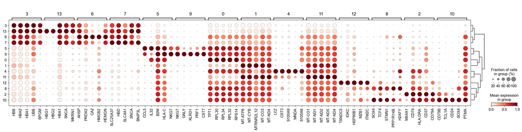

```python
#Visualize top five differentially-expressed genes on the dotplot.
sc.pl.rank_genes_groups_dotplot(adata, groupby="louvain_r0.50", standard_scale="var", n_genes=5)
```

- 이 유전자 정보를 바탕으로 cell type을 추적할 수 있다.
- 예를 들어 NKG7과 GNLY 유전자가 발현하는 세포는 NK cell이라고 표현하는 추정하는 것이다.
- `rank_genes_groups_df` 기능을 통해 쉽게 cell type을 추적할 수 있다.

```python
sc.get.rank_genes_groups_df(adata, group="7").head(5)
```

|  | names | scores | logfoldchanges | pvals | pvals_adj |
| --- | --- | --- | --- | --- | --- |
| 0 | SLC25A37 | 39.038994 | 4.656274 | 0.000000e+00 | 0.000000e+00 |
| 1 | HBD | 37.567478 | 5.613297 | 7.303832e-309 | 8.555344e-305 |
| 2 | SLC4A1 | 37.281067 | 4.512066 | 3.326465e-304 | 2.597636e-300 |
| 3 | SNCA | 36.082432 | 3.996270 | 4.277791e-285 | 2.505395e-281 |
| 4 | BNIP3L | 35.853527 | 3.495852 | 1.620502e-281 | 6.778621e-278 |

- 위 내용은 clustering 방법이 louvain이었기 때문인지 튜토리얼 내용과 매우 상반되게 나왔다.
- Clustering 방법이 얼마나 데이터 분석에 큰 영향을 끼치는지 알 수 있다.

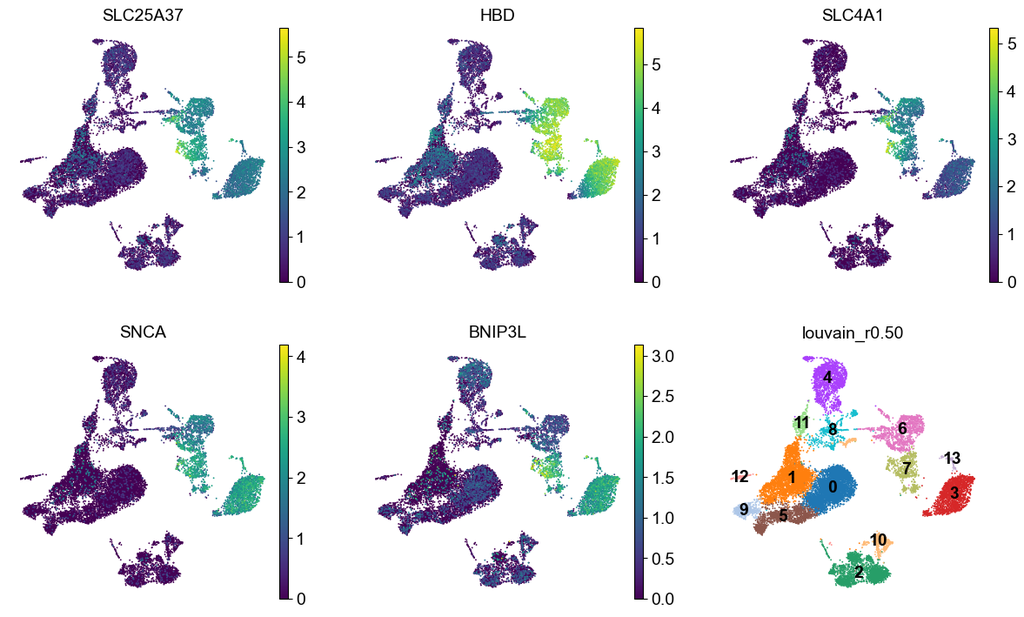

```python
#Visualize the cell type
dc_cluster_genes = sc.get.rank_genes_groups_df(adata, group="7").head(5)["names"]
sc.pl.umap(adata, color=[*dc_cluster_genes, "louvain_r0.50"], legend_loc="on data", frameon=False, ncols=3)
```